# lab1_final

## GROUP MEMBERS

- **Alex Chen**
- **Paige Maple**
- **Sam Valentine**

### Business Understanding (1.5 pts)

1. **Overview of the Dataset and Its Purpose**  
   The **Education Inequality Data** dataset ([Kaggle link](https://www.kaggle.com/datasets/shamimhasan8/education-inequality-data)) provides information on about 1,000 schools in the United States. It includes data such as **average test scores, funding per student, student–teacher ratio, and other school-level indicators**. The purpose of collecting this kind of data is to highlight patterns of inequality in the education system and to provide a basis for studying how different factors affect student performance. By bringing together financial, structural, and outcome-related information, the dataset allows us to explore whether students in underfunded or overcrowded schools are at a disadvantage compared to those in better-resourced schools.
2. **Prediction Task**  
   For our project, the **prediction task** is centered on the **average test score**. Instead of treating it as a continuous number, we will convert it into a **binary classification problem**: a school “passes” if its average test score is **≥ 70 (coded as 1)** and “fails” if the average is **below 70 (coded as 0)**. This framing allows us to study the conditions that increase the likelihood of passing or failing. While funding per student is an important feature, it is **not the only one that matters**. Other variables such as student–teacher ratio, overall enrollment, or demographic factors may also play a role in determining whether a school performs well. By including multiple features, we can better understand how resources and other conditions collectively influence student success.
3. **Why This Matters and Performance Expectations**  
   The results of this prediction task would be useful for **educators, school administrators, policymakers, and nonprofits**. These groups care about identifying schools that are likely to struggle so they can allocate resources, design interventions, and advocate for more equitable policies. A model that can predict pass/fail outcomes with reasonably **high accuracy** would provide valuable insights, even if it is not perfect. For example, being able to correctly classify most schools would still help highlight patterns of inequality and guide decision-making. Importantly, since funding is not the sole determinant of student performance, the model could also reveal how other school characteristics contribute to success or failure, offering a more balanced and realistic understanding of the factors behind educational outcomes.

### Data Understanding (3 pts)

#### Part 1 (1.5 pts)

```python
import numpy as np
import pandas as pd

# load the dataset
df = pd.read_csv("../dataset/education_inequality_data.csv")

# change avg_test_score to categorical data (1 for pass and 0 for fail) and change the name to pass/fail
df["avg_test_score_percent"] = (df["avg_test_score_percent"] >= 70).astype(int)
df = df.rename(columns={"avg_test_score_percent": "passed"})

# show basic info
df.info()
df.head()
```

```
<class 'pandas.core.frame.DataFrame'>
RangeIndex: 1000 entries, 0 to 999
Data columns (total 12 columns):
 #   Column                   Non-Null Count  Dtype
---  ------                   --------------  -----
 0   id                       1000 non-null   int64
 1   school_name              1000 non-null   object
 2   state                    1000 non-null   object
 3   school_type              1000 non-null   object
 4   grade_level              1000 non-null   object
 5   funding_per_student_usd  1000 non-null   float64
 6   passed                   1000 non-null   int32
 7   student_teacher_ratio    1000 non-null   float64
 8   percent_low_income       1000 non-null   float64
 9   percent_minority         1000 non-null   float64
 10  internet_access_percent  1000 non-null   float64
 11  dropout_rate_percent     1000 non-null   float64
dtypes: float64(6), int32(1), int64(1), object(4)
memory usage: 90.0+ KB
```

|  | id | school_name | state | school_type | grade_level | funding_per_student_usd | passed | student_teacher_ratio | percent_low_income | percent_minority | internet_access_percent | dropout_rate_percent |
| --- | --- | --- | --- | --- | --- | --- | --- | --- | --- | --- | --- | --- |
| 0 | 1 | Bowman High School | Michigan | Private | High | 9575.80 | 0 | 17.5 | 30.0 | 44.0 | 74.1 | 3.44 |
| 1 | 2 | Foster High School | Michigan | Charter | Middle | 16733.10 | 1 | 24.2 | 93.5 | 40.1 | 79.9 | 8.67 |
| 2 | 3 | Henson High School | New York | Public | Middle | 24890.74 | 1 | 27.0 | 58.1 | 35.8 | 51.1 | 14.75 |
| 3 | 4 | Weaver High School | Texas | Private | Elementary | 6857.49 | 1 | 26.2 | 82.7 | 72.0 | 55.5 | 13.45 |
| 4 | 5 | King Elementary School | Michigan | Public | Elementary | 16910.73 | 0 | 20.2 | 41.4 | 16.1 | 57.8 | 6.98 |

We created a table to show the 12 attributes within the dataset along with their desired data type and a short discussion of each attribute.

| Column | Data Type | Discussion |
| --- | --- | --- |
| id | Categorical (identifier) | The school id is just a unique identifier and should not affect the pass/fail rate. |
| school_name | Categorical (nominal) | Each school name is unique; it does not influence performance directly and is not useful for prediction. |
| state | Categorical (nominal) | Indicates the U.S. state; may capture regional differences in funding and outcomes. |
| school_type | Categorical (nominal) | Public, Private, or Charter; school type may influence resources and outcomes. |
| grade_level | Categorical (ordinal) | Elementary, Middle, High; has an inherent order, but often treated as nominal in modeling. |
| funding_per_student_usd | Numeric (continuous) | Measures financial resources per student; a central factor in studying inequality. |
| pass/fail | Categorical (binary) | Target variable (1 = pass, 0 = fail); represents the classification outcome. |
| student_teacher_ratio | Numeric (continuous) | Lower ratios may reflect more support per student, influencing success rates. |
| percent_low_income | Numeric (continuous) | Higher percentages may correlate with additional challenges in student outcomes. |
| percent_minority | Numeric (continuous) | Reflects demographic composition; may highlight systemic inequalities. |
| internet_access_percent | Numeric (continuous) | Indicates digital access; important for modern education and performance. |
| dropout_rate_percent | Numeric (continuous) | High dropout rates often signal struggling schools and lower performance. |

#### Part 2 (1.5 pts)

```
<class 'pandas.core.frame.DataFrame'>
RangeIndex: 1000 entries, 0 to 999
Data columns (total 12 columns):
 #   Column                   Non-Null Count  Dtype
---  ------                   --------------  -----
 0   id                       1000 non-null   int64
 1   school_name              1000 non-null   object
 2   state                    1000 non-null   object
 3   school_type              1000 non-null   object
 4   grade_level              1000 non-null   object
 5   funding_per_student_usd  1000 non-null   float64
 6   passed                   1000 non-null   int32
 7   student_teacher_ratio    1000 non-null   float64
 8   percent_low_income       1000 non-null   float64
 9   percent_minority         1000 non-null   float64
 10  internet_access_percent  1000 non-null   float64
 11  dropout_rate_percent     1000 non-null   float64
dtypes: float64(6), int32(1), int64(1), object(4)
memory usage: 90.0+ KB
Duplicate rows:  0
```

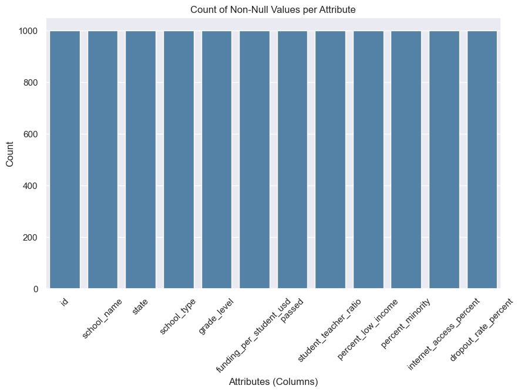

```python
import seaborn as sns
import matplotlib.pyplot as plt

df.info()
print("Duplicate rows: ", df.duplicated().sum())

attribute_counts = df.count()

# Bar chart to show completness of the dataset
plt.figure(figsize=(10,6))
sns.barplot(x=attribute_counts.index, y=attribute_counts.values, color="steelblue")
plt.xticks(rotation=45)
plt.title("Count of Non-Null Values per Attribute")
plt.ylabel("Count")
plt.xlabel("Attributes (Columns)")
plt.show()
```

We verified the dataset for data quality issues. Using `df.info()` and the bar chart, we confirmed that all 12 attributes have 1000 non-null entries, meaning there are **no missing values**. We also checked for duplicates with `df.duplicated().sum()`, which returned 0. This shows there are **no duplicate rows**. Therefore, the dataset is clean and does not require elimination or imputation, and we can proceed with analysis confidently.

### Data Visualization (4.5 pts)

#### Part One (2 pts)

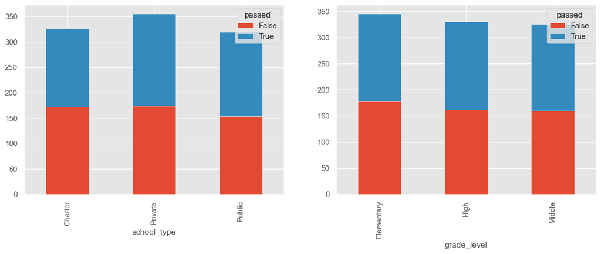

```python
import seaborn as sns
import matplotlib.pyplot as plt

plt.style.use('ggplot')

plt.figure(figsize=(15,5))
ax1 = plt.subplot(1,2,1)
ax2 = plt.subplot(1,2,2)

pd.crosstab([df['school_type']], # categories to cross tabulate
            df.passed.astype(bool)).plot(kind='bar', stacked=True, ax=ax1)

pd.crosstab([df['grade_level']], # categories to cross tabulate
            df.passed.astype(bool)).plot(kind='bar', stacked=True, ax=ax2)

plt.show()
```

#### Figure 1

We first plotted the schools by type (Public, Private, or Charter) and grade level (Elementary, Middle, High) to get an understanding of the distribution of schools that across each category, as well as the distribution of schools that passed or failed according the the category. From this plot, we can see that the amount of schools in each category is about equal, and about half of the schools in each category Passed. This indicates that these features may not correlate with passing.

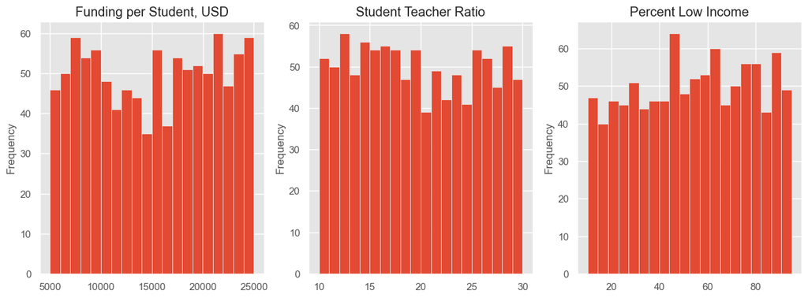

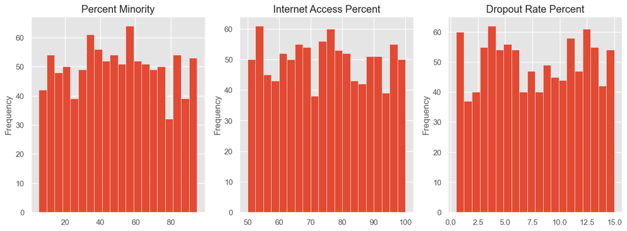

```python
fig = plt.figure(figsize=(15,5))

plt.subplot(1,3,1)
df.funding_per_student_usd.plot.hist(bins=20)
plt.title('Funding per Student, USD')

plt.subplot(1,3,2)
df.student_teacher_ratio.plot.hist(bins=20)
plt.title('Student Teacher Ratio')

plt.subplot(1,3,3)
df.percent_low_income.plot.hist(bins=20)
plt.title('Percent Low Income')

plt.show()

fig = plt.figure(figsize=(15,5))

plt.subplot(1,3,1)
df.percent_minority.plot.hist(bins=20)
plt.title('Percent Minority')

plt.subplot(1,3,2)
df.internet_access_percent.plot.hist(bins=20)
plt.title('Internet Access Percent')

plt.subplot(1,3,3)
df.dropout_rate_percent.plot.hist(bins=20)
plt.title('Dropout Rate Percent')

plt.show()
```

#### Figure 2

We plotted histograms of each of the features we excpect are important to predict passing to see the spread of each feature across the dataset. In general, there is a nearly even spread across each feature. For funding per student, there is a slight increase in the nummber of schools in the low- and high-range of the feature. This may be happening because lower fundening per student could indicate two things: high student population or low overall funding, or even a mix of both. Similarly, higher funding per student could indicate lower student population or higher overall funding.

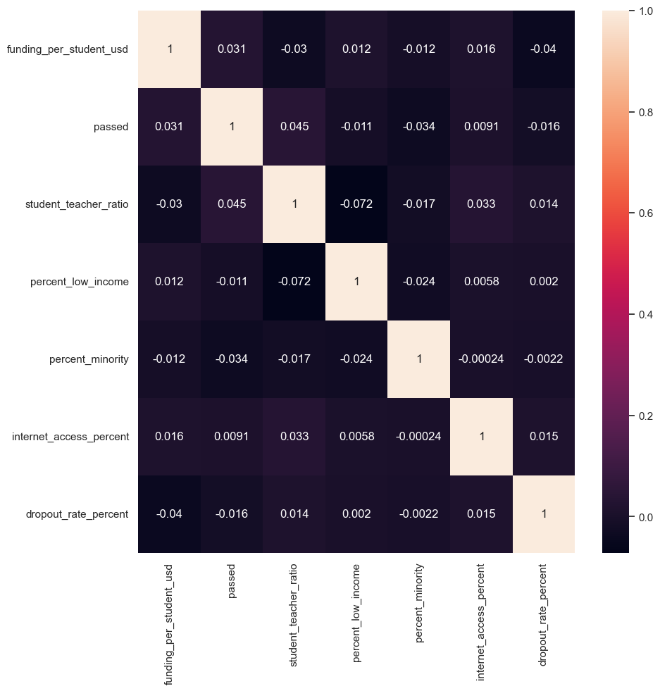

```python
vars_to_use = ['funding_per_student_usd', 'passed', 'student_teacher_ratio', 'percent_low_income', 'percent_minority','internet_access_percent','dropout_rate_percent']

cmap = sns.set(style="darkgrid") # one of the many styles to plot using

f, ax = plt.subplots(figsize=(10, 10))
sns.heatmap(df[vars_to_use].corr(), cmap=cmap, annot=True)
```

#### Figure 3

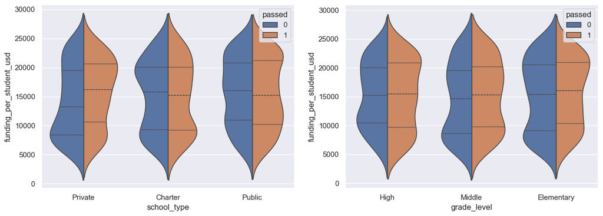

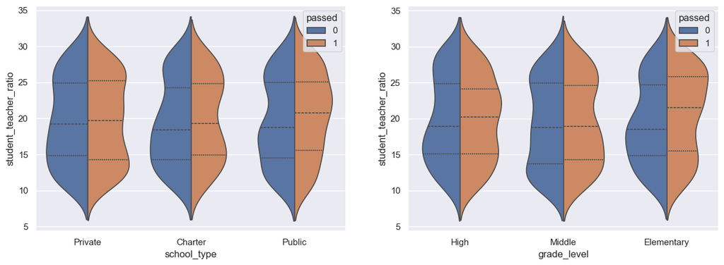

```python
fig = plt.figure(figsize=(15,5))

plt.subplot(1,2,1)
sns.violinplot(x = 'school_type', y = 'funding_per_student_usd', hue="passed", data = df,
               split=True,
              inner="quart",
              density_norm="count")
plt.subplot(1,2,2)
sns.violinplot(x = 'grade_level', y = 'funding_per_student_usd', hue="passed", data = df,
               split=True,
              inner="quart",
              density_norm="count")
plt.show()

fig = plt.figure(figsize=(15,5))

plt.subplot(1,2,1)
sns.violinplot(x = 'school_type', y = 'student_teacher_ratio', hue="passed", data = df,
               split=True,
              inner="quart",
              density_norm="count")
plt.subplot(1,2,2)
sns.violinplot(x = 'grade_level', y = 'student_teacher_ratio', hue="passed", data = df,
               split=True,
              inner="quart",
              density_norm="count")

plt.show()
```

#### Figure 4

There may be some correlation between certain features and pass/fail within the different school types and grade levels. It may be valuable to group by school type and grade level, then plot feature correlation.

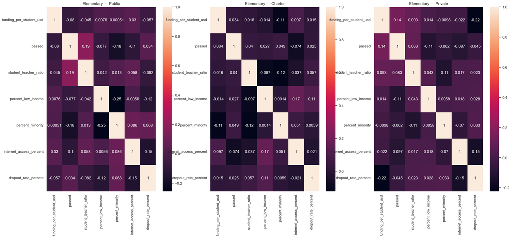

```python
#grouping by grade level and school type
df_grouped = df.copy()
grouped = df_grouped.groupby(['grade_level', 'school_type'])

#plotting feature correlation for each of the subgroups we just created
df_ele_pub = grouped.get_group(('Elementary', 'Public'))
df_ele_cha = grouped.get_group(('Elementary', 'Charter'))
df_ele_pri = grouped.get_group(('Elementary', 'Private'))

vars_to_use = ['funding_per_student_usd', 'passed', 'student_teacher_ratio', 'percent_low_income', 'percent_minority','internet_access_percent','dropout_rate_percent']

cmap = sns.set(style="darkgrid") # one of the many styles to plot using

plt.figure(figsize=(25,10))
plt.subplot(1,3,1)
sns.heatmap(df_ele_pub[vars_to_use].corr(), cmap=cmap, annot=True)
plt.title('Elementary — Public')

plt.subplot(1,3,2)
sns.heatmap(df_ele_cha[vars_to_use].corr(), cmap=cmap, annot=True)
plt.title('Elementary — Charter')

plt.subplot(1,3,3)
sns.heatmap(df_ele_pri[vars_to_use].corr(), cmap=cmap, annot=True)
plt.title('Elementary — Private')

plt.show()
```

#### Figure 5

We grouped the dataset by school type and then grade level and plotted the feature correlation heat map for the elementary school data. There is now much stronger correlation across the features than before. For the public elementaries, a stronger correlation of 0.19 with student teacher ratio, as well as a stronger correlation of -0.18 with percent minority. For the charter elementaries, we still see very low correlation with each of the features and passing. Indeed, the strongest correlation we see is 0.17 between percent low income and internet access percent. For the private elementaries, we see a stronger correlation of 0.14 between funding per student and passing, as well as a stronger negative correlation with percent low income and passing of -0.11.

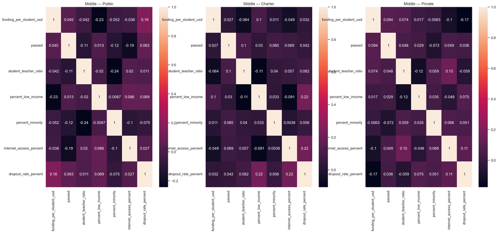

```python
df_mid_pub = grouped.get_group(('Middle', 'Public'))
df_mid_cha = grouped.get_group(('Middle', 'Charter'))
df_mid_pri = grouped.get_group(('Middle', 'Private'))

vars_to_use = ['funding_per_student_usd', 'passed', 'student_teacher_ratio', 'percent_low_income', 'percent_minority','internet_access_percent','dropout_rate_percent']

cmap = sns.set(style="darkgrid") # one of the many styles to plot using

#plotting feature correlation for each of the subgroups we just created
plt.figure(figsize=(25,10))

plt.subplot(1,3,1)
sns.heatmap(df_mid_pub[vars_to_use].corr(), cmap=cmap, annot=True)
plt.title('Middle — Public')

plt.subplot(1,3,2)
sns.heatmap(df_mid_cha[vars_to_use].corr(), cmap=cmap, annot=True)
plt.title('Middle — Charter')

plt.subplot(1,3,3)
sns.heatmap(df_mid_pri[vars_to_use].corr(), cmap=cmap, annot=True)
plt.title('Middle — Private')

plt.show()
```

#### Figure 6

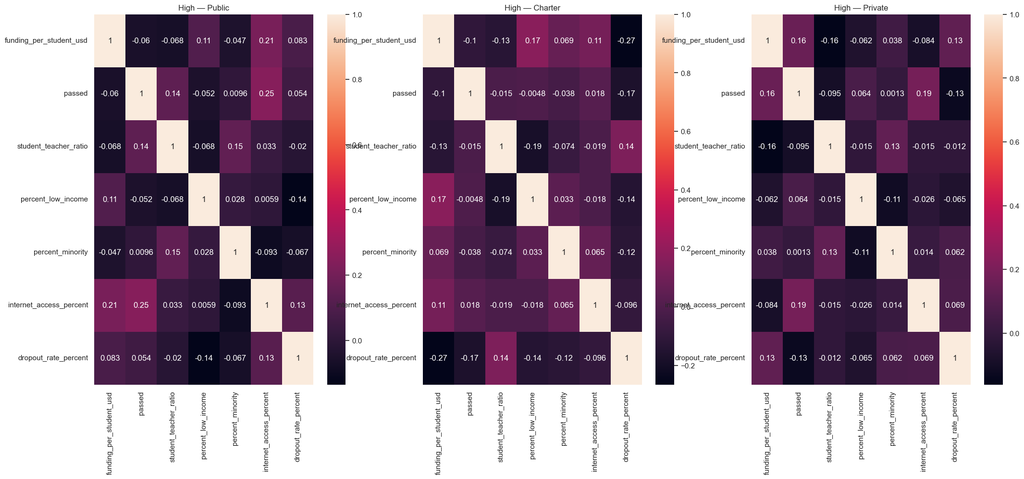

```python
df_high_pub = grouped.get_group(('High', 'Public'))
df_high_cha = grouped.get_group(('High', 'Charter'))
df_high_pri = grouped.get_group(('High', 'Private'))

vars_to_use = ['funding_per_student_usd', 'passed', 'student_teacher_ratio', 'percent_low_income', 'percent_minority','internet_access_percent','dropout_rate_percent']

cmap = sns.set(style="darkgrid") # one of the many styles to plot using

#plotting feature correlation for each of the subgroups we just created
plt.figure(figsize=(25,10))

plt.subplot(1,3,1)
sns.heatmap(df_high_pub[vars_to_use].corr(), cmap=cmap, annot=True)
plt.title('High — Public')

plt.subplot(1,3,2)
sns.heatmap(df_high_cha[vars_to_use].corr(), cmap=cmap, annot=True)
plt.title('High — Charter')

plt.subplot(1,3,3)
sns.heatmap(df_high_pri[vars_to_use].corr(), cmap=cmap, annot=True)
plt.title('High — Private')

plt.show()
```

#### Part Two (2.5 pts)

### Questions & Analysis

#### 1. What are the universal features of a school that indicate a school passing ~50% of its student population (average test score is 70% or higher)?

The initial feature correlation plot indicates only slight correlations across all features. This is surprising. One would think that the school funding and student-to-teacher ratio would be very solid indicators of test performance universally, but this is clearly not the case. There are a few reasons why this might be the case. [Fig. 3]

- The data is not clear about what the “tests” being averaged actually are. If these statistics are from standardized tests, it has been shown that standardized test statistics are highly variable and are not always the best gauge of an education or a student. Schools with fewer resources are still required to meet government regulations concerning standardized tests. Thus, these institutions will emphasize teaching to these tests in order to adhere to policy and maintain funding. The tests could also be tests administered throughout the course of a school year. There are other concerns about whether test averages can be compared universally. For instance, schools with more funding per student may be able to offer AP/Honors courses that are more challenging, such that while the students may be better prepared for college, their test averages are comparable to test averages from lesser schools. [1]
- This dataset does not capture public policy aside from the differences between Charter, Public, & Private Schools. The dataset is too small to effectively capture differences in state departments of education. However, it is well known that different states have different expectations regarding public youth education. The largest group of schools is from Texas (~12%) giving a slim total of 120 schools to then be compared to even smaller state sub-groups. Public policy, however, greatly affects education standards, most directly public education standards, and should be more effectively accounted for in a study such as this [2]

The average test score is a more complex feature that cannot be effectively predicted across all schools within the dataset without the inclusion of more features.

#### 2. Do different types of schools have different indicating features that can be used to predict 50% of their student population passing their tests?

It is possible that high amounts variation in the school types: Elementary, Middle, and High Schools, coupled with Charter, Private, and Public versions of each, for a total of 9 discrete schooling environments captured in the data, may be affecting our ability to pick strong correlations out of the data.. Theoretically, private elementary schools and public high schools could behave completely differently solely based on their served demographics and funding structures. Therefore, we should categorically split the data and search for indicating features that way. When this is done, these correlation plots yield much stronger results but still largely demonstrate a lack of significant correlation. However, there are a few notable statistics. Public elementary and high schools exhibit relatively stronger correlations with high test percentages and, unintuitively, higher student to teacher ratios [Fig. 5, 7]. It is possible that more involved parents might press for their children to attend public schools with better reputations, which could skew the data such that public schools with slightly higher student-to-teacher ratios perform better on tests. For each of these instances, a higher student-to-teacher ratio is slightly negatively correlated with the dropout rate. For private elementary and high schools, more funding per student is correlated with higher test scores, which makes sense [Fig. 4, 5, 7]. In high schools, for both public and private schools, the most predictive feature seems to be the percentage of students with internet access [Fig. 4, 7]. Internet Access is a key feature of a successful modern education system, as it enhances student study sessions and makes communicating with other students and staff easier. Charter high schools' test scores had a relatively strong negative correlation with their dropout rates, but this seems more like a symptom of good/bad test scores rather than a cause [Fig. 5 - 7]. Middle Schools had no strong predictive features [Fig. 6]. This may just be because middle schoolers are strange, and thus the relevant features in the data that their schools produce will be difficult to constrain as well. Charter schools were also challenging to predict because they are publicly funded, but don't necessarily have the same strict curricula as public schools. [3] The learning environment in Charter schools may vary wildly, such that this subgroup is comparable in variation to the entire dataset.

#### 3. Are dropout rates in charter schools better predicted by other parameters than in more traditional learning environments?

With the exception of private elementary schools, which have dropout rates strongly correlated with funding/student and internet access, yes! This is because Charter school attendance is more voluntary compared to public schools and less prestigious than private schools. That means that if students and their parents are unhappy with their experience, they are more likely to drop out, and attend their local public school instead. Charter school curricula can be flexible, experimental, and not for everyone, so it makes sense that students might be more easily disgruntled and prompted to leave. [Fig. 5-7][3]

### Exceptional Work (1 pts)

#### Part One (0.4 pts)

We hypothesized that the funding per student and student-to-teacher ratios would be strong predictors of high test scores across all schools, and we were incorrect. However, the results published do make sense upon further investigation. Education systems are complex and the capability of understanding of that complexity is not fully captured in the limited features present in this dataset.

### Sources

1. https://www.nea.org/nea-today/all-news-articles/standardized-testing-still-failing-students
2. https://feed.georgetown.edu/access-affordability/ap-courses-falling-short-as-a-tool-for-narrowing-equity-gaps/
3. https://www.usnews.com/education/k12/articles/understanding-charter-schools-vs-public-schools
4. ChatGPT (For formatting text and plots)

#### Part Two (UMAP) (0.6 pts)

```
Selected columns for UMAP: ['funding_per_student_usd', 'student_teacher_ratio', 'percent_low_income', 'percent_minority', 'internet_access_percent', 'dropout_rate_percent']
```

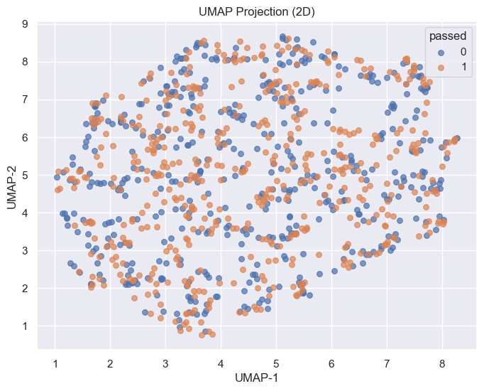

```python
from sklearn.preprocessing import StandardScaler
import umap.umap_ as umap

# Select numeric feature data and exclude id (identifier) and pass/fail (prediction task)
X = df.select_dtypes(include=["number"]).drop(columns=["id", "passed"])
print("Selected columns for UMAP:", list(X))
# Scale before embedding
X_scaled = StandardScaler().fit_transform(X)
# UMAP embedding (reduce 6 features into 2D embeddings)
embedding = umap.UMAP(random_state=42).fit_transform(X_scaled)
# Apply labels (pass/fail)
labels = df["passed"]

# Plot
plt.figure(figsize=(8,6))
for lab in np.unique(labels):
    mask = labels == lab
    plt.scatter(embedding[mask, 0], embedding[mask, 1], s=30, alpha=0.7, label=str(lab))
plt.legend(title="passed")
plt.title("UMAP Projection (2D)")
plt.xlabel("UMAP-1")
plt.ylabel("UMAP-2")
plt.show()
```

UMAP (Uniform Manifold Approximation and Projection) is a dimensionality reduction method that is both fast and scalable, making it effective even for large datasets. UMAP constructs a high-dimensional graph of the data based on relationships similar to *k*-nearest neighbors, and then optimizes a corresponding low-dimensional graph that preserves local structure. This allows the data to be visualized in two dimensions while retaining meaningful similarities between points.

In this analysis, six numeric features were used: `funding_per_student_usd`, `student_teacher_ratio`, `percent_low_income`, `percent_minority`, `internet_access_percent`, and `dropout_rate_percent`. These features were standardized to remove scale bias, and each school was represented as a single data point in a six-dimensional space. UMAP then reduced these feature vectors into two dimensions, and the `passed` column was used only for coloring the points in the 2D plot to assess how well the features align with the outcome.

The resulting UMAP plot shows that the data points for pass and fail outcomes overlap considerably, indicating that the selected features do not produce a strong separation between the two groups. This is expected because educational outcomes such as pass/fail are influenced by many additional factors (e.g., teaching quality, curriculum, community support, and individual student characteristics) that are not included in the dataset. The overlap suggests that while these six features may carry some information related to pass/fail, they are insufficient on their own to clearly distinguish the two outcomes.